# 48_exp_base_and_stretch_eq

## 48_exp_base_and_stretch_eq

#### Question

1. For [exponential functions](https://en.wikipedia.org/wiki/Exponential_function), a horizontal stretch is equivalent to a change of base. Consider the two functions below, where $g$ is equivalent to stretching $f$ horizontally by a factor $4.5$:

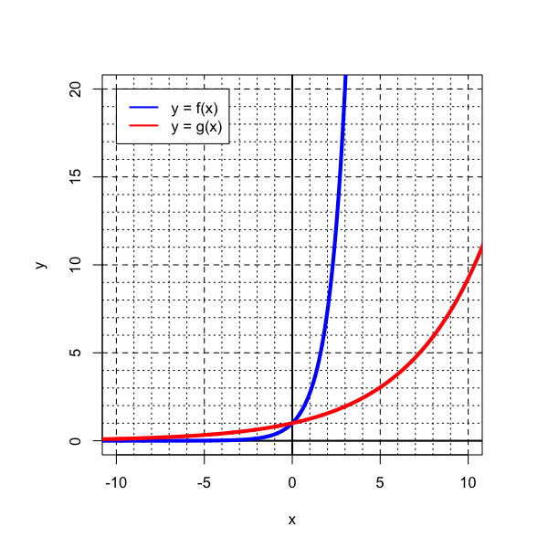

   $$\begin{align}
   f(x) &= e^{x}\\\\
   g(x) &= e^{x/4.5}
   \end{align}$$

   Instead of using the horizontal stretch transformation, we could have changed the base.

   $$g(x) = B^{x}$$

   where $B$ represents the new base.
   - Find $B$. The tolerance is $\pm 0.01$.

#### Question

2. For [exponential functions](https://en.wikipedia.org/wiki/Exponential_function), a horizontal stretch is equivalent to a change of base. Consider the two functions below, where $g$ is equivalent to stretching $f$ horizontally by a factor $2.1$:

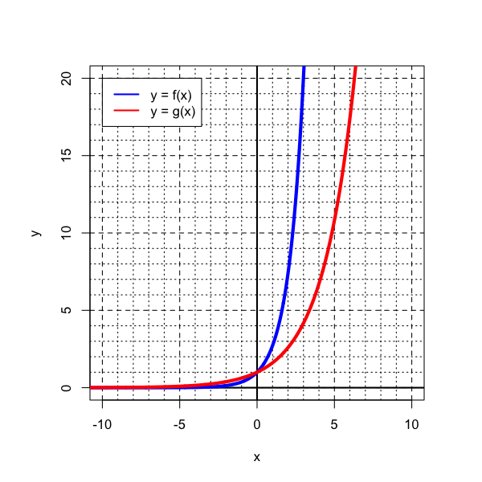

   $$\begin{align}
   f(x) &= e^{x}\\\\
   g(x) &= e^{x/2.1}
   \end{align}$$

   Instead of using the horizontal stretch transformation, we could have changed the base.

   $$g(x) = B^{x}$$

   where $B$ represents the new base.
   - Find $B$. The tolerance is $\pm 0.01$.

#### Question

3. For [exponential functions](https://en.wikipedia.org/wiki/Exponential_function), a horizontal stretch is equivalent to a change of base. Consider the two functions below, where $g$ is equivalent to stretching $f$ horizontally by a factor $3.7$:

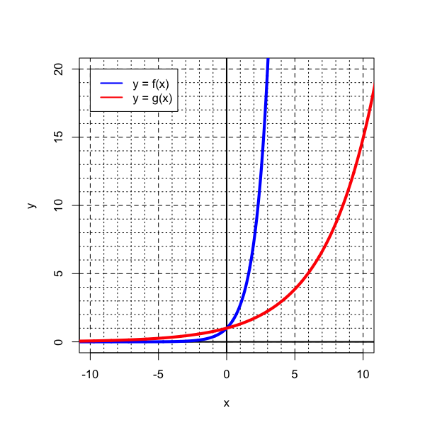

   $$\begin{align}
   f(x) &= e^{x}\\\\
   g(x) &= e^{x/3.7}
   \end{align}$$

   Instead of using the horizontal stretch transformation, we could have changed the base.

   $$g(x) = B^{x}$$

   where $B$ represents the new base.
   - Find $B$. The tolerance is $\pm 0.01$.

#### Question

4. For [exponential functions](https://en.wikipedia.org/wiki/Exponential_function), a horizontal stretch is equivalent to a change of base. Consider the two functions below, where $g$ is equivalent to stretching $f$ horizontally by a factor $3.6$:

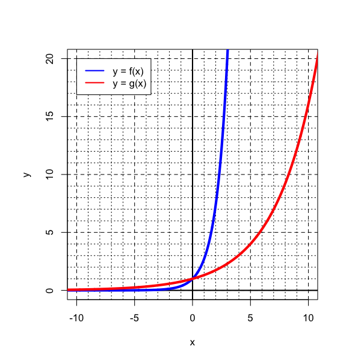

   $$\begin{align}
   f(x) &= e^{x}\\\\
   g(x) &= e^{x/3.6}
   \end{align}$$

   Instead of using the horizontal stretch transformation, we could have changed the base.

   $$g(x) = B^{x}$$

   where $B$ represents the new base.
   - Find $B$. The tolerance is $\pm 0.01$.

#### Question

5. For [exponential functions](https://en.wikipedia.org/wiki/Exponential_function), a horizontal stretch is equivalent to a change of base. Consider the two functions below, where $g$ is equivalent to stretching $f$ horizontally by a factor $4.5$:

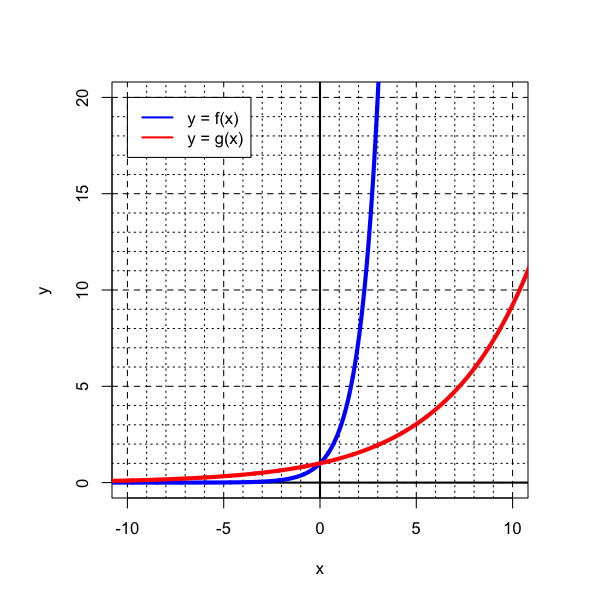

   $$\begin{align}
   f(x) &= e^{x}\\\\
   g(x) &= e^{x/4.5}
   \end{align}$$

   Instead of using the horizontal stretch transformation, we could have changed the base.

   $$g(x) = B^{x}$$

   where $B$ represents the new base.
   - Find $B$. The tolerance is $\pm 0.01$.

#### Question

6. For [exponential functions](https://en.wikipedia.org/wiki/Exponential_function), a horizontal stretch is equivalent to a change of base. Consider the two functions below, where $g$ is equivalent to stretching $f$ horizontally by a factor $2.6$:

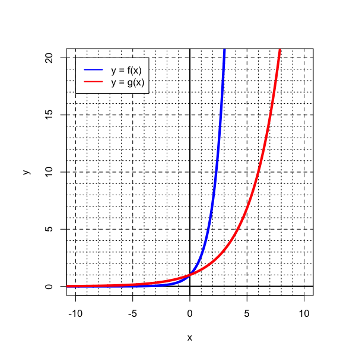

   $$\begin{align}
   f(x) &= e^{x}\\\\
   g(x) &= e^{x/2.6}
   \end{align}$$

   Instead of using the horizontal stretch transformation, we could have changed the base.

   $$g(x) = B^{x}$$

   where $B$ represents the new base.
   - Find $B$. The tolerance is $\pm 0.01$.

#### Question

7. For [exponential functions](https://en.wikipedia.org/wiki/Exponential_function), a horizontal stretch is equivalent to a change of base. Consider the two functions below, where $g$ is equivalent to stretching $f$ horizontally by a factor $3.6$:

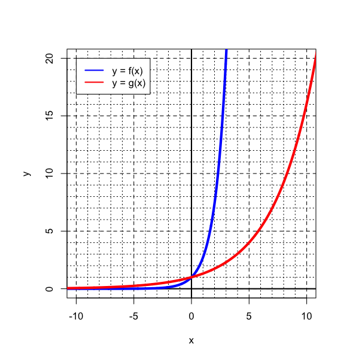

   $$\begin{align}
   f(x) &= e^{x}\\\\
   g(x) &= e^{x/3.6}
   \end{align}$$

   Instead of using the horizontal stretch transformation, we could have changed the base.

   $$g(x) = B^{x}$$

   where $B$ represents the new base.
   - Find $B$. The tolerance is $\pm 0.01$.

#### Question

8. For [exponential functions](https://en.wikipedia.org/wiki/Exponential_function), a horizontal stretch is equivalent to a change of base. Consider the two functions below, where $g$ is equivalent to stretching $f$ horizontally by a factor $2.1$:

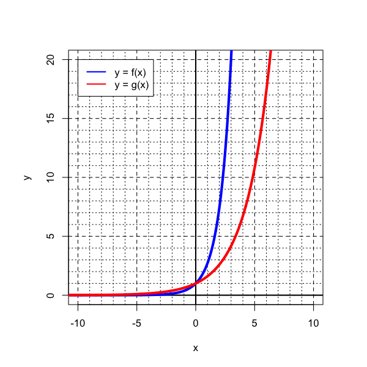

   $$\begin{align}
   f(x) &= e^{x}\\\\
   g(x) &= e^{x/2.1}
   \end{align}$$

   Instead of using the horizontal stretch transformation, we could have changed the base.

   $$g(x) = B^{x}$$

   where $B$ represents the new base.
   - Find $B$. The tolerance is $\pm 0.01$.